# Tutoriel R Markdown

Guide complet pour la rédaction de rapports scientifiques

# 1 Introduction à R Markdown

## 1.1 Qu’est-ce que R Markdown ?

**R Markdown** est un format de document qui permet de **combiner du texte, du code R et des résultats** dans un seul document. Il est idéal pour :

- Rédiger des **rapports scientifiques** reproductibles
- Créer des **analyses statistiques** documentées
- Produire des **présentations** ou des **documents PDF/HTML**
- Partager vos **analyses en aquaculture** de manière professionnelle

## 1.2 Structure d’un document R Markdown

Un document R Markdown (.Rmd) contient trois éléments principaux :

1. **En-tête YAML** (métadonnées du document)
2. **Texte en Markdown** (texte formaté)
3. **Chunks de code R** (code exécutable)

# 2 L’en-tête YAML

L’en-tête YAML se trouve **au début du document** entre deux lignes de trois tirets `---`.

## 2.1 Exemple d’en-tête de base

```yaml
---
title: "Analyse de la croissance du bar"
author: "Jean Dupont"
date: "2025-12-07"
output: html_document
---
```

## 2.2 Options de sortie

### 2.2.1 HTML interactif

```yaml
output:
  html_document:
    toc: true                # Table des matières
    toc_float: true          # Sommaire flottant
    toc_depth: 3             # Profondeur du sommaire
    number_sections: true    # Numérotation automatique
    theme: cosmo             # Thème visuel
    highlight: tango         # Coloration syntaxique
    code_folding: hide       # Cacher le code par défaut
```

**Thèmes disponibles** : `default`, `cerulean`, `cosmo`, `flatly`, `journal`, `lumen`, `paper`, `readable`, `sandstone`, `simplex`, `spacelab`, `united`, `yeti`

### 2.2.2 PDF professionnel

```yaml
output:
  pdf_document:
    toc: true
    number_sections: true
    latex_engine: xelatex    # Meilleur support des caractères
    fig_caption: true        # Légendes des figures
```

### 2.2.3 Plusieurs formats

```yaml
output:
  html_document:
    toc: true
  pdf_document:
    toc: true
  word_document:
    toc: true
```

# 3 Mise en forme du texte

## 3.1 Titres et sections

```markdown
# Titre de niveau 1
## Titre de niveau 2
### Titre de niveau 3
#### Titre de niveau 4
```

### 3.1.1 Exemple en aquaculture

# 4 Étude de la croissance de la daurade royale

## 4.1 Matériel et méthodes

### 4.1.1 Site d’étude

L’expérience a été menée dans une ferme aquacole méditerranéenne.

### 4.1.2 Mesures biométriques

Les poissons ont été pesés et mesurés hebdomadairement.

## 4.2 Formatage du texte

| Syntaxe | Rendu | Exemple aquaculture |
| --- | --- | --- |
| `*italique*` ou `_italique_` | *italique* | *Sparus aurata* (nom d’espèce) |
| `**gras**` ou `__gras__` | **gras** | **Température optimale : 24°C** |
| `***gras italique***` | *gras italique* | *Attention : stress thermique* |
| `` `code` `` | `code` | Variable `temperature` |
| `~~barré~~` | barré | Ancienne méthode |

### 4.2.1 Exemple pratique

```markdown
L'espèce étudiée est la *daurade royale* (*Sparus aurata*).
La **température de l'eau** est un facteur critique.
***IMPORTANT*** : Maintenir l'oxygène > 5 mg/L.
La fonction `lm()` permet de modéliser la croissance.
```

**Rendu** :

L’espèce étudiée est la *daurade royale* (*Sparus aurata*). La **température de l’eau** est un facteur critique. *IMPORTANT* : Maintenir l’oxygène > 5 mg/L. La fonction `lm()` permet de modéliser la croissance.

## 4.3 Listes

### 4.3.1 Liste à puces

```markdown
Facteurs influençant la croissance :

- Température de l'eau
- Concentration en oxygène dissous
- Densité d'élevage
  - Faible densité : < 10 kg/m³
  - Haute densité : > 20 kg/m³
- Qualité de l'aliment
```

**Rendu** :

Facteurs influençant la croissance :

- Température de l’eau
- Concentration en oxygène dissous
- Densité d’élevage
  - Faible densité : < 10 kg/m³
  - Haute densité : > 20 kg/m³
- Qualité de l’aliment

### 4.3.2 Liste numérotée

```markdown
Protocole expérimental :

1. Acclimation des poissons (7 jours)
2. Mesure des paramètres initiaux
   a. Poids individuel
   b. Longueur totale
3. Application des traitements
4. Mesures hebdomadaires
5. Analyse statistique
```

**Rendu** :

Protocole expérimental :

1. Acclimation des poissons (7 jours)
2. Mesure des paramètres initiaux
   1. Poids individuel
   2. Longueur totale
3. Application des traitements
4. Mesures hebdomadaires
5. Analyse statistique

## 4.4 Liens et images

### 4.4.1 Liens hypertextes

```markdown
[Site de la FAO sur l'aquaculture](https://www.fao.org/aquaculture/fr)
```

**Rendu** : [Site de la FAO sur l’aquaculture](https://www.fao.org/aquaculture/fr)

### 4.4.2 Images

```markdown
![Daurade royale](chemin/vers/image.jpg)
![Daurade royale](image.jpg){width=50%}
```

## 4.5 Tableaux

```markdown
| Espèce | Température optimale (°C) | Croissance (g/jour) |
|--------|---------------------------|---------------------|
| Daurade royale | 22-26 | 2.5 |
| Bar européen | 20-24 | 2.0 |
| Loup de mer | 18-22 | 1.8 |
```

**Rendu** :

| Espèce | Température optimale (°C) | Croissance (g/jour) |
| --- | --- | --- |
| Daurade royale | 22-26 | 2.5 |
| Bar européen | 20-24 | 2.0 |
| Loup de mer | 18-22 | 1.8 |

### 4.5.1 Alignement dans les tableaux

```markdown
| Gauche | Centre | Droite |
|:-------|:------:|-------:|
| A | B | C |
```

- `:---` = aligné à gauche
- `:---:` = centré
- `---:` = aligné à droite

# 5 Formules mathématiques

R Markdown utilise **LaTeX** pour les formules mathématiques.

## 5.1 Formules en ligne

Utilisez `$...$` pour insérer une formule dans le texte.

```markdown
Le taux de croissance spécifique est calculé par : $SGR = \frac{\ln(W_f) - \ln(W_i)}{t} \times 100$
```

**Rendu** :

Le taux de croissance spécifique est calculé par : $SGR = \frac{\ln(W_f) - \ln(W_i)}{t} \times 100$

## 5.2 Formules centrées

Utilisez `$$...$$` pour une formule sur sa propre ligne.

```markdown
$$
FCR = \frac{\text{Aliment distribué (kg)}}{\text{Gain de poids (kg)}}
$$
```

**Rendu** :

$$FCR = \frac{\text{Aliment distribué (kg)}}{\text{Gain de poids (kg)}}$$

## 5.3 Exemples de formules en aquaculture

### 5.3.1 Taux de croissance spécifique (SGR)

```markdown
$$
SGR = \frac{\ln(W_f) - \ln(W_i)}{t} \times 100
$$

où $W_f$ = poids final, $W_i$ = poids initial, $t$ = durée (jours)
```

**Rendu** :

$$SGR = \frac{\ln(W_f) - \ln(W_i)}{t} \times 100$$

où $W_f$ = poids final, $W_i$ = poids initial, $t$ = durée (jours)

### 5.3.2 Facteur de conversion alimentaire (FCR)

$$FCR = \frac{F}{W_f - W_i}$$

où $F$ = quantité d’aliment distribuée

### 5.3.3 Relation poids-longueur

$$W = a \times L^b$$

Sous forme logarithmique :

$$\ln(W) = \ln(a) + b \times \ln(L)$$

### 5.3.4 Modèle de von Bertalanffy

$$L_t = L_\infty \left(1 - e^{-K(t - t_0)}\right)$$

où :

- $L_t$ = longueur au temps $t$
- $L_\infty$ = longueur asymptotique
- $K$ = coefficient de croissance
- $t_0$ = âge théorique à longueur nulle

### 5.3.5 Indices statistiques

Moyenne : $\bar{x} = \frac{1}{n}\sum_{i=1}^n x_i$

Écart-type : $s = \sqrt{\frac{1}{n-1}\sum_{i=1}^n (x_i - \bar{x})^2}$

Coefficient de variation : $CV = \frac{s}{\bar{x}} \times 100$

## 5.4 Symboles mathématiques courants

| Code LaTeX | Symbole | Utilisation aquaculture |
| --- | --- | --- |
| `\alpha` | $\alpha$ | Seuil de significativité |
| `\beta` | $\beta$ | Coefficient de régression |
| `\mu` | $\mu$ | Moyenne de population |
| `\sigma` | $\sigma$ | Écart-type de population |
| `\pm` | $\pm$ | Plus ou moins (erreur) |
| `\leq` | $\leq$ | Inférieur ou égal |
| `\geq` | $\geq$ | Supérieur ou égal |
| `\times` | $\times$ | Multiplication |
| `\approx` | $\approx$ | Approximativement |
| `\neq` | $\neq$ | Différent de |

# 6 Chunks de code R

## 6.1 Structure d’un chunk

Un chunk de code R commence par `` ```{r} `` et se termine par `` ``` ``.

````markdown
``` r
# Votre code R ici
x <- 1:10
mean(x)
```

```
## [1] 5.5
```
````

## 6.2 Nommage des chunks

Il est **recommandé** de nommer vos chunks pour faciliter la navigation et le débogage.

````markdown
``` r
biomasse <- poids_moyen * nombre_poissons
biomasse
```
````

## 6.3 Options des chunks

Les options se placent dans l’en-tête du chunk : `` ```{r nom-chunk, option1=valeur1, option2=valeur2} ``

### 6.3.1 Options principales

| Option | Valeurs | Description | Exemple aquaculture |
| --- | --- | --- | --- |
| `echo` | `TRUE`/`FALSE` | Afficher le code | `echo=FALSE` pour rapport final |
| `eval` | `TRUE`/`FALSE` | Exécuter le code | `eval=FALSE` pour exemple |
| `include` | `TRUE`/`FALSE` | Inclure chunk dans le rendu | `include=FALSE` pour setup |
| `results` | `'markup'`, `'hide'`, `'hold'`, `'asis'` | Format des résultats | `results='asis'` pour tableaux |
| `message` | `TRUE`/`FALSE` | Afficher les messages | `message=FALSE` pour packages |
| `warning` | `TRUE`/`FALSE` | Afficher les warnings | `warning=FALSE` |
| `error` | `TRUE`/`FALSE` | Continuer si erreur | `error=TRUE` pour démo |
| `fig.width` | nombre | Largeur figure (pouces) | `fig.width=10` |
| `fig.height` | nombre | Hauteur figure (pouces) | `fig.height=6` |
| `fig.cap` | texte | Légende de la figure | `fig.cap="Croissance du bar"` |
| `fig.align` | `'left'`, `'center'`, `'right'` | Alignement figure | `fig.align='center'` |

### 6.3.2 Exemples pratiques

#### 6.3.2.1 Chunk setup (caché)

**Rendu** : Rien n’apparaît dans le document (chunk exécuté en coulisse).

#### 6.3.2.2 Afficher uniquement le résultat

**Rendu** : Seul le résultat s’affiche, pas le code.

```
## [1] 56625
```

#### 6.3.2.3 Afficher le code sans l’exécuter

````markdown
``` r
# Calcul du SGR (non exécuté)
SGR <- (log(poids_final) - log(poids_initial)) / duree * 100
```
````

**Rendu** : Le code s’affiche mais n’est pas exécuté.

```r
# Calcul du SGR
SGR <- (log(poids_final) - log(poids_initial)) / duree * 100
```

#### 6.3.2.4 Figure avec légende

````markdown
``` r
temps <- c(0, 30, 60, 90, 120)
poids <- c(5, 25, 55, 95, 145)

plot(temps, poids, type = "b", pch = 19, col = "blue",
     xlab = "Temps (jours)", ylab = "Poids moyen (g)",
     main = "Croissance de Sparus aurata")
```
````

**Rendu** :

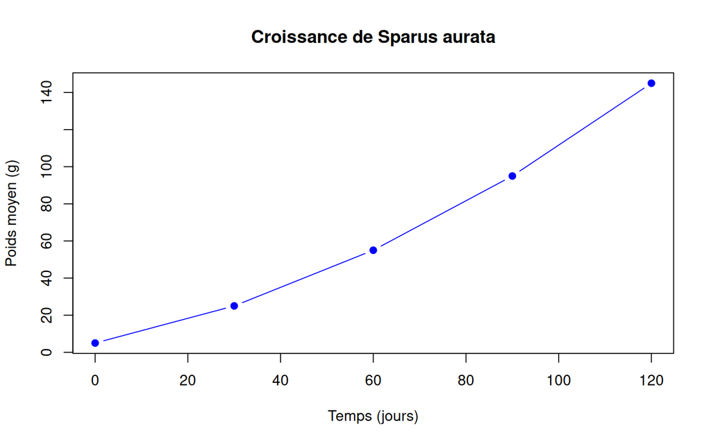

Évolution du poids moyen de la daurade en fonction du temps

## 6.4 Chunks en ligne

Vous pouvez insérer du code R directement dans le texte avec `` `r ` ``.

```markdown
La biomasse totale est de 56.62 kg.
```

**Rendu** :

La biomasse totale est de 56.62 kg.

# 7 Exemple complet : Analyse de croissance

## 7.1 Chargement et exploration des données

```r
# Statistiques descriptives
summary(daurade)
```

```
##   temperature       oxygene     poids_initial     poids_final
##  Min.   :19.10   Min.   :4.70   Min.   : 5.900   Min.   :29.00
##  1st Qu.:21.90   1st Qu.:6.20   1st Qu.: 8.100   1st Qu.:33.90
##  Median :22.85   Median :6.60   Median : 9.400   Median :36.40
##  Mean   :23.07   Mean   :6.61   Mean   : 9.496   Mean   :36.01
##  3rd Qu.:24.40   3rd Qu.:7.00   3rd Qu.:10.575   3rd Qu.:38.58
##  Max.   :27.30   Max.   :8.20   Max.   :14.200   Max.   :45.00
##       SGR
##  Min.   :1.073
##  1st Qu.:1.377
##  Median :1.501
##  Mean   :1.499
##  3rd Qu.:1.635
##  Max.   :1.896
```

```r
# Nombre d'observations
nrow(daurade)
```

```
## [1] 50
```

## 7.2 Visualisation

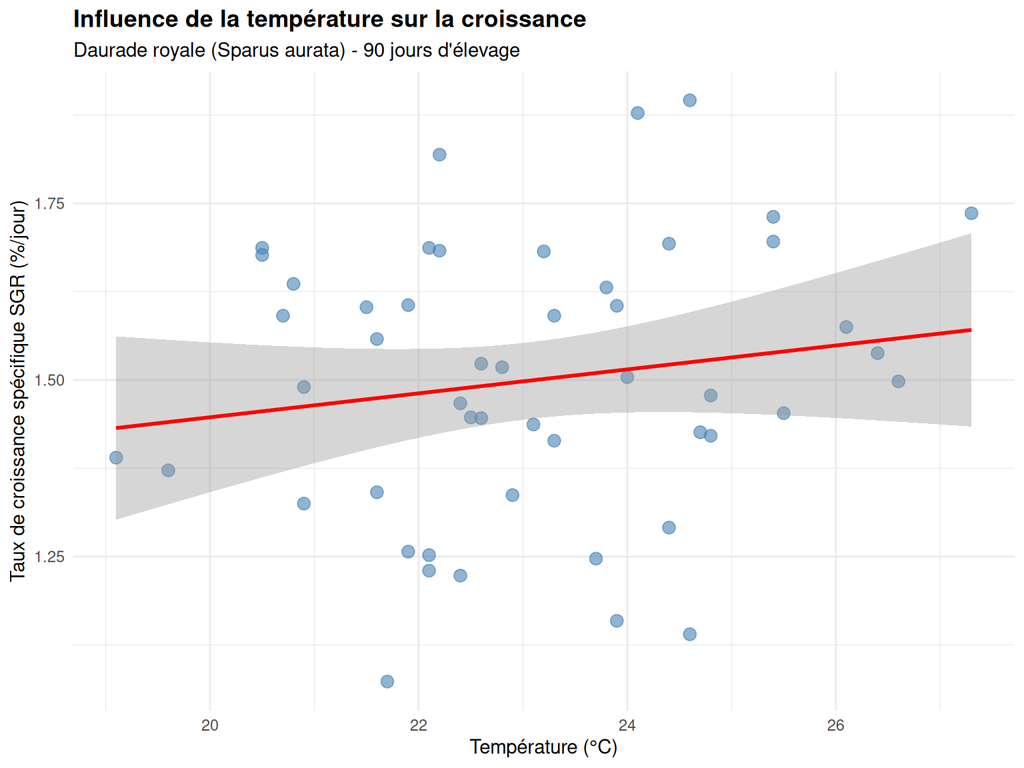

Relation entre température et taux de croissance spécifique (SGR)

```r
library(ggplot2)

ggplot(daurade, aes(x = temperature, y = SGR)) +
  geom_point(color = "steelblue", size = 3, alpha = 0.6) +
  geom_smooth(method = "lm", se = TRUE, color = "red") +
  labs(
    title = "Influence de la température sur la croissance",
    subtitle = "Daurade royale (Sparus aurata) - 90 jours d'élevage",
    x = "Température (°C)",
    y = "Taux de croissance spécifique SGR (%/jour)"
  ) +
  theme_minimal() +
  theme(plot.title = element_text(face = "bold"))
```

## 7.3 Analyse statistique

```r
# Modèle de régression linéaire
modele <- lm(SGR ~ temperature + oxygene, data = daurade)
summary(modele)
```

```
##
## Call:
## lm(formula = SGR ~ temperature + oxygene, data = daurade)
##
## Residuals:
##      Min       1Q   Median       3Q      Max
## -0.36859 -0.10685 -0.02729  0.14144  0.38741
##
## Coefficients:
##             Estimate Std. Error t value Pr(>|t|)
## (Intercept)  0.72237    0.42435   1.702   0.0953 .
## temperature  0.01755    0.01459   1.203   0.2351
## oxygene      0.05629    0.03752   1.500   0.1403
## ---
## Signif. codes:  0 '***' 0.001 '**' 0.01 '*' 0.05 '.' 0.1 ' ' 1
##
## Residual standard error: 0.1886 on 47 degrees of freedom
## Multiple R-squared:  0.07114,    Adjusted R-squared:  0.03162
## F-statistic:   1.8 on 2 and 47 DF,  p-value: 0.1765
```

## 7.4 Tableau récapitulatif

```r
library(knitr)

stats <- daurade %>%
  summarise(
    `Température moyenne (°C)` = round(mean(temperature), 1),
    `Oxygène moyen (mg/L)` = round(mean(oxygene), 1),
    `Poids initial moyen (g)` = round(mean(poids_initial), 1),
    `Poids final moyen (g)` = round(mean(poids_final), 1),
    `SGR moyen (%/jour)` = round(mean(SGR), 3)
  )

kable(stats, caption = "Statistiques descriptives de l'expérience")
```

Statistiques descriptives de l’expérience

| Température moyenne (°C) | Oxygène moyen (mg/L) | Poids initial moyen (g) | Poids final moyen (g) | SGR moyen (%/jour) |
| --- | --- | --- | --- | --- |
| 23.1 | 6.6 | 9.5 | 36 | 1.499 |

# 8 Blocs spéciaux

## 8.1 Notes et avertissements (HTML uniquement)

### 8.1.1 Note informative

```markdown
> **Note** : La température optimale pour la daurade se situe entre 22 et 26°C.
```

**Rendu** :

> **Note** : La température optimale pour la daurade se situe entre 22 et 26°C.

### 8.1.2 Avertissement

```markdown
> **⚠️ Attention** : Des températures > 28°C peuvent causer un stress thermique.
```

**Rendu** :

> **⚠️ Attention** : Des températures > 28°C peuvent causer un stress thermique.

## 8.2 Bloc de citation

```markdown
> "L'aquaculture est l'une des industries alimentaires à la croissance la plus rapide au monde."
>
> --- FAO, 2022
```

**Rendu** :

> “L’aquaculture est l’une des industries alimentaires à la croissance la plus rapide au monde.”

> — FAO, 2022

## 8.3 Code non-R

### 8.3.1 SQL

````markdown
```sql
SELECT espece, AVG(poids) as poids_moyen
FROM poissons
WHERE temperature BETWEEN 20 AND 25
GROUP BY espece;
```
````

### 8.3.2 Python

````markdown
```python
import pandas as pd
data = pd.read_csv("croissance.csv")
print(data.describe())
```
````

# 9 Astuces avancées

## 9.1 Options globales des chunks

Définir des options par défaut dans le chunk `setup` :

```r
knitr::opts_chunk$set(
  echo = TRUE,          # Afficher le code par défaut
  warning = FALSE,      # Masquer les warnings
  message = FALSE,      # Masquer les messages
  fig.width = 8,        # Largeur par défaut des figures
  fig.height = 6,       # Hauteur par défaut
  fig.align = "center", # Centrer les figures
  cache = FALSE         # Désactiver le cache
)
```

## 9.2 Insertion de date automatique

Dans l’en-tête YAML :

```yaml
date: "2025-12-08"
```

Ou en français :

```yaml
date: "08 décembre 2025"
```

## 9.3 Bibliographie

Ajouter des références bibliographiques :

1. Créer un fichier `references.bib`
2. Ajouter dans l’en-tête YAML :

```yaml
bibliography: references.bib
```

3. Citer dans le texte : `[@auteur2023]`

# 10 Rendu du document

## 10.1 Depuis RStudio

1. Cliquer sur le bouton **Knit** (ou Ctrl+Shift+K)
2. Choisir le format : HTML, PDF ou Word

## 10.2 Depuis la console R

```r
# HTML
rmarkdown::render("mon_rapport.Rmd", output_format = "html_document")

# PDF
rmarkdown::render("mon_rapport.Rmd", output_format = "pdf_document")

# Word
rmarkdown::render("mon_rapport.Rmd", output_format = "word_document")

# Tous les formats
rmarkdown::render("mon_rapport.Rmd", output_format = "all")
```

# 11 Ressources complémentaires

## 11.1 Documentation officielle

- [R Markdown: The Definitive Guide](https://bookdown.org/yihui/rmarkdown/)
- [R Markdown Cheat Sheet](https://www.rstudio.com/resources/cheatsheets/)
- [R Markdown Reference Guide](https://www.rstudio.com/wp-content/uploads/2015/03/rmarkdown-reference.pdf)

## 11.2 Packages utiles

```r
# Tableaux élégants
install.packages("kableExtra")
install.packages("gt")
install.packages("flextable")

# Graphiques interactifs
install.packages("plotly")
install.packages("DT")

# Diagrammes
install.packages("DiagrammeR")
```

## 11.3 Exemples de templates

```r
# Créer un nouveau document avec template
rmarkdown::draft("mon_rapport.Rmd", template = "html_document", package = "rmarkdown")
```